# Project 4: Bank Marketing

January 5th 2020

## Overview

This document contains instructions on Project 4 for STA 207 in Winter 2020. This document is made with `R markdown`. The `rmd` file to generate this document is available on the course website.

## Background

A Portuguese retail bank started a telemarketing campaign in 2008, aiming to subscribe new users to a long-term deposit. Information collected during the campaign was recorded in this data set. More information is available on the UCI machine learning repository ([link](https://archive.ics.uci.edu/ml/datasets/Bank+Marketing#)) and the citations therein.

You are a consultant who is hired to study the retail banking market in Portugese. Somehow you come to know such a dataset is publicly available. Naturally, you want to gain some insights of the market from this dataset, before conducting an expensive survey.

## Tasks

```r
library(ggplot2)
library(caret) # Accuracy
library(e1071)
library(rpart)
library(rpart.plot)
library(rattle)
library(randomForest)
library(caTools)
library(descr)
library(MASS)
library(klaR)
library(FNN)
library(partykit)
library(pROC)
library(latticeExtra)
```

1. Acquire the dataset from the UCI machine learning repository ([link](https://archive.ics.uci.edu/ml/datasets/Bank+Marketing#)).

```r
library(data.table)
temp <- tempfile()
download.file('https://archive.ics.uci.edu/ml/machine-learning-databases/00222/bank-additional.zip', temp)
data  <- read.table(unzip(zipfile = temp,
                                     files = 'bank-additional/bank-additional-full.csv',
                                     junkpaths = TRUE), header = TRUE, sep = ';')
#Using Local Dataset location
#data <- read.csv(file="./bank-additional-full.csv", header=TRUE, sep=";")
```

2. Pick an appropriate data set to study, and justify your decision.

```r
#summary of data
dim(data)
```

```
## [1] 41188    21
```

```r
names(data)
```

```
##  [1] "age"            "job"            "marital"        "education"
##  [5] "default"        "housing"        "loan"           "contact"
##  [9] "month"          "day_of_week"    "duration"       "campaign"
## [13] "pdays"          "previous"       "poutcome"       "emp.var.rate"
## [17] "cons.price.idx" "cons.conf.idx"  "euribor3m"      "nr.employed"
## [21] "y"
```

```r
# Check for any missing values:
sum(is.na(data))
```

```
## [1] 0
```

```r
str(data)
```

```
## 'data.frame':    41188 obs. of  21 variables:
##  $ age           : int  56 57 37 40 56 45 59 41 24 25 ...
##  $ job           : Factor w/ 12 levels "admin.","blue-collar",..: 4 8 8 1 8 8 1 2 10 8 ...
##  $ marital       : Factor w/ 4 levels "divorced","married",..: 2 2 2 2 2 2 2 2 3 3 ...
##  $ education     : Factor w/ 8 levels "basic.4y","basic.6y",..: 1 4 4 2 4 3 6 8 6 4 ...
##  $ default       : Factor w/ 3 levels "no","unknown",..: 1 2 1 1 1 2 1 2 1 1 ...
##  $ housing       : Factor w/ 3 levels "no","unknown",..: 1 1 3 1 1 1 1 1 3 3 ...
##  $ loan          : Factor w/ 3 levels "no","unknown",..: 1 1 1 1 3 1 1 1 1 1 ...
##  $ contact       : Factor w/ 2 levels "cellular","telephone": 2 2 2 2 2 2 2 2 2 2 ...
##  $ month         : Factor w/ 10 levels "apr","aug","dec",..: 7 7 7 7 7 7 7 7 7 7 ...
##  $ day_of_week   : Factor w/ 5 levels "fri","mon","thu",..: 2 2 2 2 2 2 2 2 2 2 ...
##  $ duration      : int  261 149 226 151 307 198 139 217 380 50 ...
##  $ campaign      : int  1 1 1 1 1 1 1 1 1 1 ...
##  $ pdays         : int  999 999 999 999 999 999 999 999 999 999 ...
##  $ previous      : int  0 0 0 0 0 0 0 0 0 0 ...
##  $ poutcome      : Factor w/ 3 levels "failure","nonexistent",..: 2 2 2 2 2 2 2 2 2 2 ...
##  $ emp.var.rate  : num  1.1 1.1 1.1 1.1 1.1 1.1 1.1 1.1 1.1 1.1 ...
##  $ cons.price.idx: num  94 94 94 94 94 ...
##  $ cons.conf.idx : num  -36.4 -36.4 -36.4 -36.4 -36.4 -36.4 -36.4 -36.4 -36.4 -36.4 ...
##  $ euribor3m     : num  4.86 4.86 4.86 4.86 4.86 ...
##  $ nr.employed   : num  5191 5191 5191 5191 5191 ...
##  $ y             : Factor w/ 2 levels "no","yes": 1 1 1 1 1 1 1 1 1 1 ...
```

```r
#summary before cleaning
summary(data)
```

```
##       age                 job            marital
##  Min.   :17.00   admin.     :10422   divorced: 4612
##  1st Qu.:32.00   blue-collar: 9254   married :24928
##  Median :38.00   technician : 6743   single  :11568
##  Mean   :40.02   services   : 3969   unknown :   80
##  3rd Qu.:47.00   management : 2924
##  Max.   :98.00   retired    : 1720
##                  (Other)    : 6156
##                education        default         housing           loan
##  university.degree  :12168   no     :32588   no     :18622   no     :33950
##  high.school        : 9515   unknown: 8597   unknown:  990   unknown:  990
##  basic.9y           : 6045   yes    :    3   yes    :21576   yes    : 6248
##  professional.course: 5243
##  basic.4y           : 4176
##  basic.6y           : 2292
##  (Other)            : 1749
##       contact          month       day_of_week    duration
##  cellular :26144   may    :13769   fri:7827    Min.   :   0.0
##  telephone:15044   jul    : 7174   mon:8514    1st Qu.: 102.0
##                    aug    : 6178   thu:8623    Median : 180.0
##                    jun    : 5318   tue:8090    Mean   : 258.3
##                    nov    : 4101   wed:8134    3rd Qu.: 319.0
##                    apr    : 2632               Max.   :4918.0
##                    (Other): 2016
##     campaign          pdays          previous            poutcome
##  Min.   : 1.000   Min.   :  0.0   Min.   :0.000   failure    : 4252
##  1st Qu.: 1.000   1st Qu.:999.0   1st Qu.:0.000   nonexistent:35563
##  Median : 2.000   Median :999.0   Median :0.000   success    : 1373
##  Mean   : 2.568   Mean   :962.5   Mean   :0.173
##  3rd Qu.: 3.000   3rd Qu.:999.0   3rd Qu.:0.000
##  Max.   :56.000   Max.   :999.0   Max.   :7.000
##
##   emp.var.rate      cons.price.idx  cons.conf.idx     euribor3m
##  Min.   :-3.40000   Min.   :92.20   Min.   :-50.8   Min.   :0.634
##  1st Qu.:-1.80000   1st Qu.:93.08   1st Qu.:-42.7   1st Qu.:1.344
##  Median : 1.10000   Median :93.75   Median :-41.8   Median :4.857
##  Mean   : 0.08189   Mean   :93.58   Mean   :-40.5   Mean   :3.621
##  3rd Qu.: 1.40000   3rd Qu.:93.99   3rd Qu.:-36.4   3rd Qu.:4.961
##  Max.   : 1.40000   Max.   :94.77   Max.   :-26.9   Max.   :5.045
##
##   nr.employed     y
##  Min.   :4964   no :36548
##  1st Qu.:5099   yes: 4640
##  Median :5191
##  Mean   :5167
##  3rd Qu.:5228
##  Max.   :5228
##
```

By explanation, `duration` should only be included for benchmark purposes and should be discarded if the intention is to have a realistic predictive model. So we remove it in this variable.

There are more than 75% values in `pdays` are 999, which means client was not previously contacted. So we remove this variable.

There are only 3 values is “yes” for `default`, and many of them are unknown. So we remove this variable.

```r
data <- data[ , -c(5, 11, 13)]
```

3. Explore this dataset and generate summary statistics (in forms of tables or plots) that you find crucial for your clients to know.

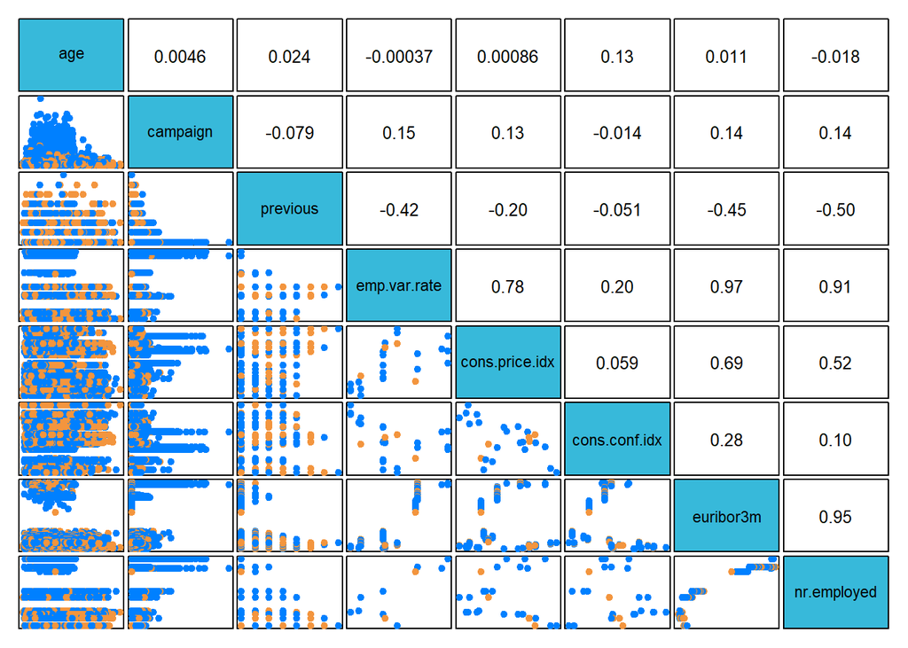

```r
quant <- data[ , c(1, 10, 11, 13:17)]
pairs(quant
      , upper.panel = function(x, y, ...) {
        usr <- par("usr") ; on.exit(par(usr)) ; par(usr = c(0, 1, 0, 1))
        r <- cor(x, y)
        txt <- format(c(r, 0.123456789), digits = 2)[1]
        text(.5, .5, txt, cex = 1.25)
      }
      , diag.panel = function(a, b, ...) {
        usr <- par("usr") ; on.exit(par(usr)) ; par(usr = c(0, 1, 0, 1))
        rect(0, 0, 1, 1, col = "#37B9DA")
      }
      , pch = 19, gap = .25, xaxt = "n", yaxt = "n"
      , col = c("#0080FF", "#F3953E")[data$y]
      , label.pos = .5, oma = c(1, 1, 1, 1))
```

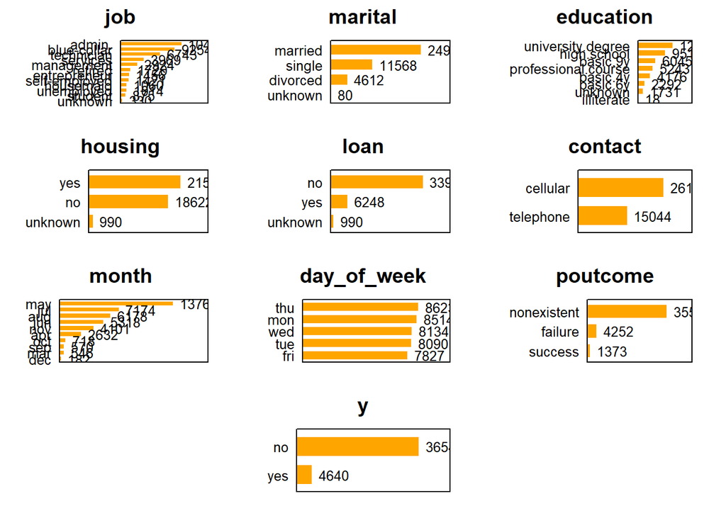

```r
barras <- function(variable, nome, limite) {
  da = table(variable)
  barchart(sort(da)
           , col = "orange"
           , border = "transparent"
           , xlab = NULL
           , main = nome
           , scales = list(x = list(draw = FALSE))
           , xlim = limite
           , panel = function(...){
             panel.barchart(...)
             args <- list(...)
             panel.text(args$x, args$y, args$x, pos = 4, cex = .8)})
}
print(barras(data$job, "job", c(0, 15e3)),
      position = c(0, 3/4, 1/3, 1), more = TRUE)
print(barras(data$marital, "marital", c(0, 33e3)),
      position = c(1/3, 3/4, 2/3, 1), more = TRUE)
print(barras(data$education, "education", c(0, 19e3)),
      position = c(2/3, 3/4, 1, 1), more = TRUE)
print(barras(data$housing, "housing", c(0, 28e3)),
      position = c(0, 2/4, 1/3, 3/4), more = TRUE)
print(barras(data$loan, "loan", c(0, 44e3)),
      position = c(1/3, 2/4, 2/3, 3/4), more = TRUE)
print(barras(data$contact, "contact", c(0, 35e3)),
      position = c(2/3, 2/4, 1, 3/4), more = TRUE)
print(barras(data$month, "month", c(0, 18e3)),
      position = c(0, 1/4, 1/3, 2/4), more = TRUE)
print(barras(data$day_of_week, "day_of_week", c(0, 11e3)),
      position = c(1/3, 1/4, 2/3, 2/4), more = TRUE)
print(barras(data$poutcome, "poutcome", c(0, 47e3)),
      position = c(2/3, 1/4, 1, 2/4), more = TRUE)
print(barras(data$y, "y", c(0, 46e3)),
      position = c(1/3, 0, 2/3, 1/4))
```

```r
#choose 10% as test data
id <- sample(1:nrow(data), round(nrow(data) / 10, 0))

train <- data[-id, ] ; test <- data[id, ]
```

4. Build a predictive model for whether a client will sign on to a long-term deposit. You will use logistic regression in this task. Specifically, you will
   1. write down a property logistic regression model,
   2. fit the model,
   3. evaluate the performance of the fitted model,
   4. and conduct model diagnostic and/or sensitivity analysis.

```r
logist <- glm(y ~ ., family = binomial, train) ; logist <- stepAIC(logist)
```

```r
summary(logist)
```

```
##
## Call:
## glm(formula = y ~ job + contact + month + day_of_week + campaign +
##     poutcome + emp.var.rate + cons.price.idx + cons.conf.idx +
##     euribor3m + nr.employed, family = binomial, data = train)
##
## Deviance Residuals:
##     Min       1Q   Median       3Q      Max
## -2.0568  -0.3910  -0.3213  -0.2631   2.9414
##
## Coefficients:
##                       Estimate Std. Error z value Pr(>|z|)
## (Intercept)         -2.216e+02  3.513e+01  -6.309 2.81e-10 ***
## jobblue-collar      -2.301e-01  5.894e-02  -3.905 9.44e-05 ***
## jobentrepreneur     -1.163e-01  1.127e-01  -1.031 0.302375
## jobhousemaid        -1.800e-01  1.297e-01  -1.387 0.165369
## jobmanagement       -1.414e-02  7.699e-02  -0.184 0.854313
## jobretired           1.784e-01  7.939e-02   2.248 0.024596 *
## jobself-employed    -7.452e-02  1.059e-01  -0.704 0.481697
## jobservices         -1.890e-01  7.539e-02  -2.507 0.012174 *
## jobstudent           2.071e-01  9.661e-02   2.144 0.032057 *
## jobtechnician       -8.951e-03  5.850e-02  -0.153 0.878390
## jobunemployed       -5.437e-02  1.147e-01  -0.474 0.635475
## jobunknown          -3.145e-01  2.244e-01  -1.402 0.161001
## contacttelephone    -7.395e-01  7.066e-02 -10.465  < 2e-16 ***
## monthaug             4.590e-01  1.134e-01   4.046 5.20e-05 ***
## monthdec             3.879e-01  1.976e-01   1.963 0.049627 *
## monthjul             4.195e-02  8.728e-02   0.481 0.630799
## monthjun            -6.693e-01  1.166e-01  -5.742 9.37e-09 ***
## monthmar             1.526e+00  1.377e-01  11.082  < 2e-16 ***
## monthmay            -4.554e-01  7.568e-02  -6.017 1.77e-09 ***
## monthnov            -4.652e-01  1.104e-01  -4.212 2.53e-05 ***
## monthoct            -1.360e-03  1.435e-01  -0.009 0.992441
## monthsep             2.536e-01  1.668e-01   1.520 0.128491
## day_of_weekmon      -2.141e-01  6.119e-02  -3.498 0.000468 ***
## day_of_weekthu       9.815e-02  5.871e-02   1.672 0.094563 .
## day_of_weektue       4.944e-02  6.078e-02   0.813 0.415940
## day_of_weekwed       1.811e-01  6.009e-02   3.014 0.002577 **
## campaign            -4.592e-02  9.743e-03  -4.713 2.44e-06 ***
## poutcomenonexistent  4.675e-01  5.835e-02   8.011 1.14e-15 ***
## poutcomesuccess      1.756e+00  8.277e-02  21.213  < 2e-16 ***
## emp.var.rate        -1.479e+00  1.308e-01 -11.307  < 2e-16 ***
## cons.price.idx       2.043e+00  2.314e-01   8.829  < 2e-16 ***
## cons.conf.idx        2.599e-02  7.400e-03   3.513 0.000444 ***
## euribor3m            2.477e-01  1.213e-01   2.043 0.041076 *
## nr.employed          5.498e-03  2.862e-03   1.921 0.054677 .
## ---
## Signif. codes:  0 '***' 0.001 '**' 0.01 '*' 0.05 '.' 0.1 ' ' 1
##
## (Dispersion parameter for binomial family taken to be 1)
##
##     Null deviance: 25979  on 37068  degrees of freedom
## Residual deviance: 20442  on 37035  degrees of freedom
## AIC: 20510
##
## Number of Fisher Scoring iterations: 6
```

5. Build another predictive model using random forest, and compare its performance compared to the logistic regression.

```r
bag <- randomForest(x = train[, -18], y = train[ , 18], importance = FALSE)
```

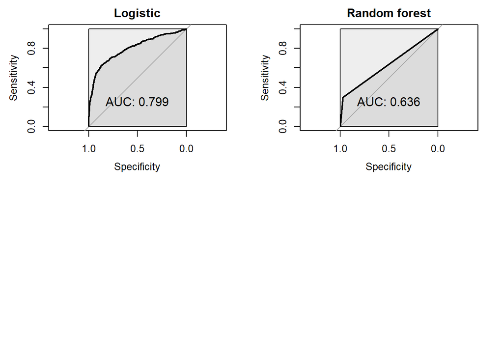

```r
par(mfrow = c(2, 2))
# ---------------------------------------------------------- logistic regression #
plot.roc(roc(test$y, predict(logist, test, type = "response"))
         , main = "Logistic"
         #, print.thres = TRUE
         , print.auc = TRUE, print.auc.cex = 1.25, print.auc.adj = c(.5, 3)
         , auc.polygon = TRUE, max.auc.polygon = TRUE)
# ------------------------------------------------------------ --- random forest #
plot.roc(roc(test$y, as.numeric(predict(bag, test)))
         , main = "Random forest"
         #, print.thres = TRUE
         , print.auc = TRUE, print.auc.cex = 1.25, print.auc.adj = c(.5, 3)
         , auc.polygon = TRUE, max.auc.polygon = TRUE)
```

6. Explain the possible gap in the performances to your supervisor, who knows statistics quite well and only believes in data and mathematics.  
7. Test whether having a house loan will increase the likelihood of a client to sign up for a long-term deposit. (Hint: you don’t need to use the same model as in Task 4.) 8. Explain your conclusion from the test to your clients who know little about statistics.

In any of these tasks, if a statistical method is employed, you need to clearly state the model and justify your choice.